# Homework-03

STAT 5732: Introduction to R for Data Science I

Author

Affiliation

Selin Kirbas

The Ohio State University

Published

March 31, 2025

# Exercises

## R4DS 19.3.4

### Exercise 1

#### Question

Find the 48 hours (over the course of the whole year) that have the worst delays. Cross-reference it with the `weather` data. Can you see any patterns?

#### Solution

```r
# Calculate average departure delay by date & hour
worst_hours <- flights %>%
  filter(!is.na(dep_delay)) %>%
  group_by(year, month, day, hour) %>%
  summarize(
    avg_dep_delay = mean(dep_delay),
    n_flights = n()
  ) %>%
  # See hours with a reasonable number of flights
  filter(n_flights >= 10) %>%
  # Sort by average delay in descending order
  arrange(desc(avg_dep_delay)) %>%
  # Get top 48 worst hours
  head(48)

# Show worst hours
worst_hours
```

```
# A tibble: 48 × 6
# Groups:   year, month, day [17]
    year month   day  hour avg_dep_delay n_flights
   <int> <int> <int> <dbl>         <dbl>     <int>
 1  2013     4    10    20          170.        31
 2  2013     4    10    21          168.        17
 3  2013     7    28    19          156.        54
 4  2013     4    10    19          152.        41
 5  2013     4    19    19          150.        53
 6  2013     6    28    21          149.        26
 7  2013     9    12    17          147.        45
 8  2013     9     2    16          144.        45
 9  2013     7    10    19          144.        43
10  2013     9    12    20          143.        26
# ℹ 38 more rows
```

Looking at the weather data:

```r
# Make datetime from components
make_datetime_from_components <- function(year, month, day, hour) {
  make_datetime(year, month, day, hour)
}

# Add datetime column to worst_hours
worst_hours <- worst_hours %>%
  mutate(datetime = make_datetime_from_components(year, month, day, hour))

# Get weather data for worst hours
worst_hours_weather <- weather %>%
  # Create datetime column in weather
  mutate(datetime = make_datetime_from_components(year, month, day, hour)) %>%
  # Join with worst hours
  inner_join(worst_hours, by = c("datetime", "year", "month", "day", "hour")) %>%
  # Select needed columns
  select(datetime, origin, temp, humid, precip, visib, wind_speed, wind_dir, avg_dep_delay)

# Show weather during the worst delay hours
worst_hours_weather
```

```
# A tibble: 143 × 9
   datetime            origin  temp humid precip visib wind_speed wind_dir
   <dttm>              <chr>  <dbl> <dbl>  <dbl> <dbl>      <dbl>    <dbl>
 1 2013-03-08 10:00:00 EWR     32    95.7   0.19  0.5       15.0       340
 2 2013-03-08 11:00:00 EWR     32    95.7   0.13  0.75      13.8       340
 3 2013-03-08 12:00:00 EWR     33.8  95.8   0.06  1          9.21      320
 4 2013-03-08 13:00:00 EWR     34.0  93.0   0.06  1.75      10.4       340
 5 2013-03-08 17:00:00 EWR     39.9  76.3   0    10         13.8       360
 6 2013-03-18 19:00:00 EWR     32    95.7   0.11  0.75      11.5        70
 7 2013-03-18 21:00:00 EWR     33.8  95.8   0.09  3          8.06       60
 8 2013-04-10 19:00:00 EWR     59    83.3   0.17  9         12.7       120
 9 2013-04-10 20:00:00 EWR     57.9  86.6   0.05 10          0           0
10 2013-04-10 21:00:00 EWR     57.2  87.7   0    10          6.90      210
# ℹ 133 more rows
# ℹ 1 more variable: avg_dep_delay <dbl>
```

Looking if there are any patterns related to weather conditions:

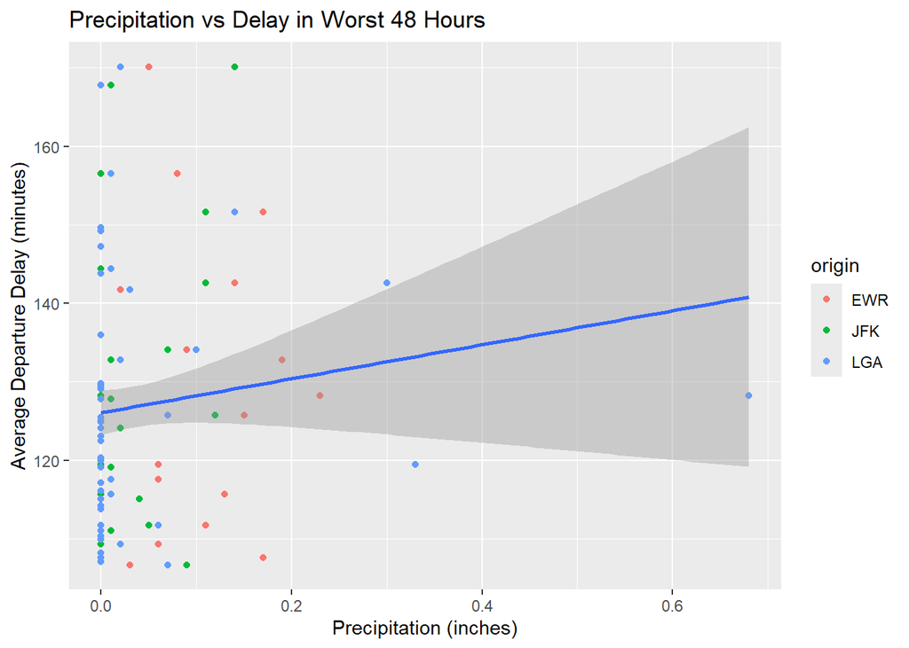

```r
# Look at precipitation during worst delay hours
ggplot(worst_hours_weather, aes(x = precip, y = avg_dep_delay)) +
  geom_point(aes(color = origin)) +
  geom_smooth(method = "lm") +
  labs(title = "Precipitation vs Delay in Worst 48 Hours",
       x = "Precipitation (inches)",
       y = "Average Departure Delay (minutes)")
```

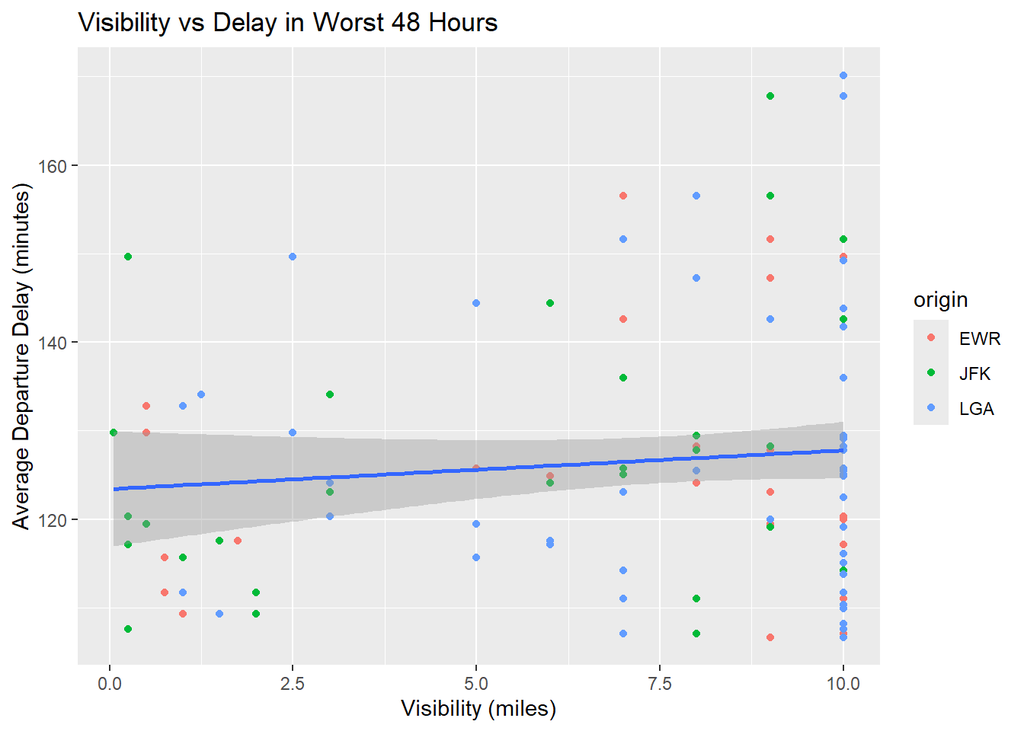

```r
# Look at visibility during worst delay hours
ggplot(worst_hours_weather, aes(x = visib, y = avg_dep_delay)) +
  geom_point(aes(color = origin)) +
  geom_smooth(method = "lm") +
  labs(title = "Visibility vs Delay in Worst 48 Hours",
       x = "Visibility (miles)",
       y = "Average Departure Delay (minutes)")
```

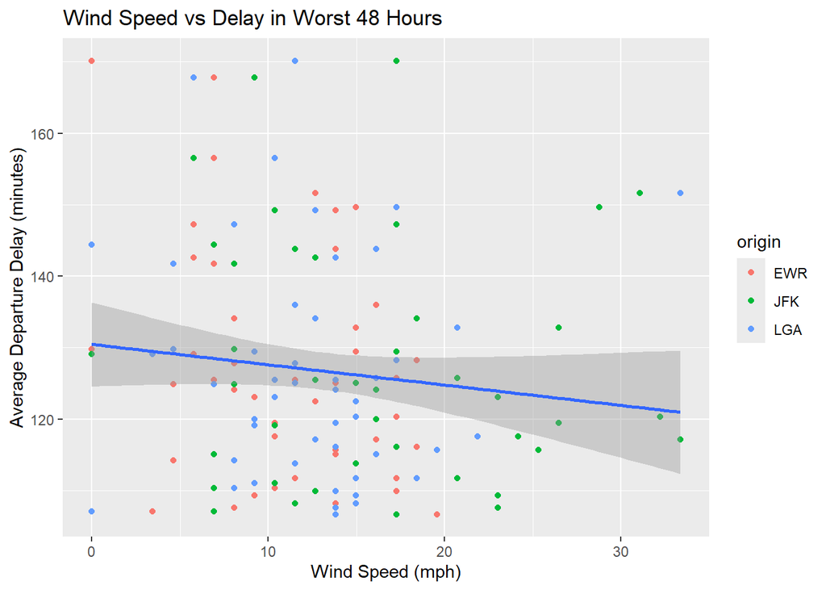

```r
# Look at wind speed during worst delay hours
ggplot(worst_hours_weather, aes(x = wind_speed, y = avg_dep_delay)) +
  geom_point(aes(color = origin)) +
  geom_smooth(method = "lm") +
  labs(title = "Wind Speed vs Delay in Worst 48 Hours",
       x = "Wind Speed (mph)",
       y = "Average Departure Delay (minutes)")
```

### Exercise 2

#### Question

Imagine you’ve found the top 10 most popular destinations using this code:

```r
top_dest <- flights2 |>
count(dest, sort = TRUE) |>
head(10)
```

How can you find all flights to those destinations?

#### Solution

To find all flights to the top 10 most popular destinations, I’ll make the `flights2` dataset and then identify the top 10 destinations. Then I’ll use a semi-join to see only the flights to those destinations:

```r
# Create flights2 dataset
flights2 <- flights %>%
  select(year:day, hour, origin, dest, tailnum, carrier)

# Find top 10 destinations
top_dest <- flights2 %>%
  count(dest, sort = TRUE) %>%
  head(10)

# Show top destinations
top_dest
```

```
# A tibble: 10 × 2
   dest      n
   <chr> <int>
 1 ORD   17283
 2 ATL   17215
 3 LAX   16174
 4 BOS   15508
 5 MCO   14082
 6 CLT   14064
 7 SFO   13331
 8 FLL   12055
 9 MIA   11728
10 DCA    9705
```

```r
# Use semi-join
flights_to_top_dest_semijoin <- flights2 %>%
  semi_join(top_dest, by = "dest")

# Look at sample of flights to top destinations
flights_to_top_dest_semijoin %>%
  sample_n(10)
```

```
# A tibble: 10 × 8
    year month   day  hour origin dest  tailnum carrier
   <int> <int> <int> <dbl> <chr>  <chr> <chr>   <chr>
 1  2013     6     6    19 JFK    FLL   N3758Y  DL
 2  2013     4    24     7 LGA    MIA   N3EUAA  AA
 3  2013     5    31    14 LGA    ORD   N514AA  AA
 4  2013     5    13    16 JFK    FLL   N583JB  B6
 5  2013     4    21     9 EWR    FLL   N33284  UA
 6  2013     8    18    18 EWR    ORD   N847UA  UA
 7  2013     8     6    10 EWR    LAX   N556UA  UA
 8  2013     7    19    12 JFK    SFO   N505UA  UA
 9  2013     4    24    11 LGA    BOS   N947UW  US
10  2013    10    11    17 JFK    SFO   N702TW  DL
```

To find all flights to the top 10 most popular destinations, I used a semi-join to filter the `flights2` dataset, keeping only flights where the destination matches one in the `top_dest` table.

## Additional Exercises

### Exercise 3

#### Question

Is there a relationship between the age of a plane and its delays?

#### Solution

To see if there is a relationship between the age of a plane and its delays, I’m going to take the year of manufacture from the `planes` dataset, calculate the age of each plane at the time of the flight in 2013, join this with the flights data, and see the relationship between plane age and delays

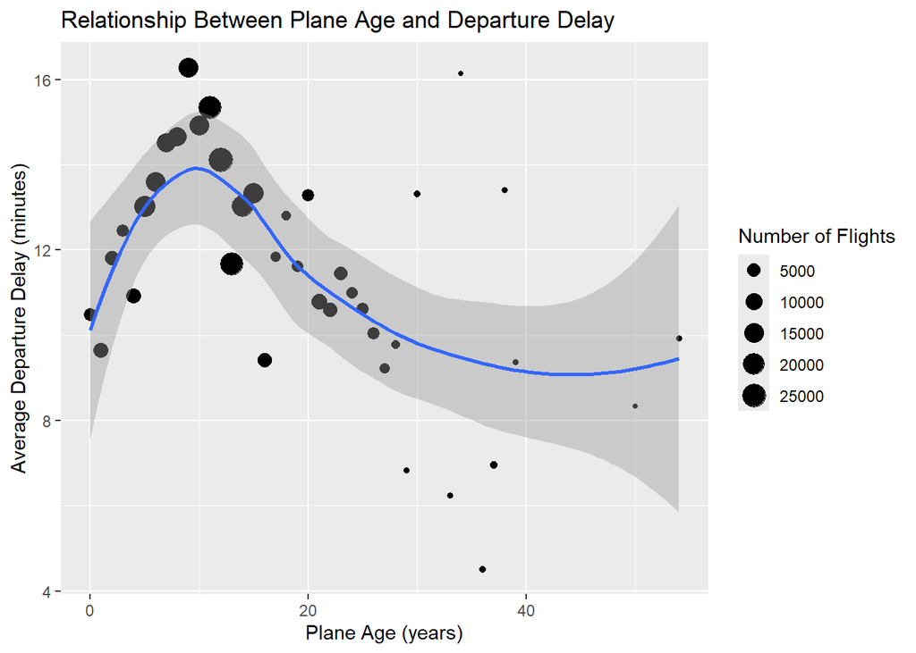

```r
# Create dataset with plane age
plane_ages <- planes %>%
  select(tailnum, year) %>%
  # Filter out planes with missing manufacture year
  filter(!is.na(year)) %>%
  # Calculate plane age as of 2013
  mutate(plane_age = 2013 - year)

# Join plane ages with flight data and delays
flights_with_age <- flights %>%
  inner_join(plane_ages, by = "tailnum") %>%
  # Show relevant delay information
  select(tailnum, dep_delay, arr_delay, plane_age) %>%
  # Remove flights with missing delay information
  filter(!is.na(dep_delay), !is.na(arr_delay))

# Calculate average delays by plane age
delay_by_age <- flights_with_age %>%
  group_by(plane_age) %>%
  summarise(
    count = n(),
    avg_dep_delay = mean(dep_delay),
    avg_arr_delay = mean(arr_delay)
  ) %>%
  # Remove ages with small number of flights
  filter(count >= 50)

# Show relationship
ggplot(delay_by_age, aes(x = plane_age, y = avg_dep_delay)) +
  geom_point(aes(size = count)) +
  geom_smooth(method = "loess") +
  labs(title = "Relationship Between Plane Age and Departure Delay",
       x = "Plane Age (years)",
       y = "Average Departure Delay (minutes)",
       size = "Number of Flights")
```

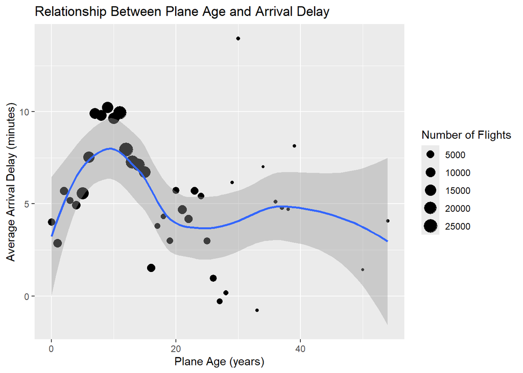

```r
ggplot(delay_by_age, aes(x = plane_age, y = avg_arr_delay)) +
  geom_point(aes(size = count)) +
  geom_smooth(method = "loess") +
  labs(title = "Relationship Between Plane Age and Arrival Delay",
       x = "Plane Age (years)",
       y = "Average Arrival Delay (minutes)",
       size = "Number of Flights")
```

```r
# Check correlation
cor.test(flights_with_age$plane_age, flights_with_age$dep_delay)
```

```
    Pearson's product-moment correlation

data:  flights_with_age$plane_age and flights_with_age$dep_delay
t = -7.9191, df = 273851, p-value = 2.401e-15
alternative hypothesis: true correlation is not equal to 0
95 percent confidence interval:
 -0.01887528 -0.01138634
sample estimates:
        cor
-0.01513102
```

```r
cor.test(flights_with_age$plane_age, flights_with_age$arr_delay)
```

```
    Pearson's product-moment correlation

data:  flights_with_age$plane_age and flights_with_age$arr_delay
t = -9.2491, df = 273851, p-value < 2.2e-16
alternative hypothesis: true correlation is not equal to 0
95 percent confidence interval:
 -0.02141544 -0.01392712
sample estimates:
        cor
-0.01767153
```

### Exercise 4

#### Question

Filter flights to only show flights with planes that have flown at least 100 flights.

#### Solution

To find flights with planes that have flown at least 100 flights, I’ll count the number of flights per plane and then filter the dataset to include only those planes:

```r
# Count flights per plane
flights_per_plane <- flights %>%
  # Avoid counting flights with missing tailnumbers
  filter(!is.na(tailnum)) %>%
  count(tailnum) %>%
  filter(n >= 100)

# See how many planes flew at least 100 flights
flights_per_plane %>%
  summarize(count = n())
```

```
# A tibble: 1 × 1
  count
  <int>
1  1217
```

```r
# Filter flights to include only those with planes that flew at least 100 flights
frequent_flyer_flights <- flights %>%
  semi_join(flights_per_plane, by = "tailnum")

# Show result
dim(flights)
```

```
[1] 336776     19
```

```r
dim(frequent_flyer_flights)
```

```
[1] 228390     19
```

I filtered the flights dataset to include only flights operated by planes that have flown at least 100 flights in 2013. Filtering removed flights with planes that had fewer than 100 flights, which gave a set that represents only the more frequently used planes. This was to make sure I was looking at planes with enough data points for a reliable analysis.